# Population,Income and Life Expectancy of Countries EDA

Suraj Radhakrishnan

February 10, 2019

The entire R code and html document are also uploaded in github under the following link. The code and HTML are in the code folder:

https://github.com/surajr92/ANLY-506-assignment

# Basic overview

This project involves the exploratory data analysis of the change in population, life expectancy and income of countries all across the world by year. The dataset used for the project contains the required data for each of these countries by region and year.

# Purpose

In this project, we will attempt to identify regions and countries that have shown the highest income and life expectancy. The project will also analyze if there is a significant change in these metrics over time. We will attempt to analyze if there is any correlation in the change of these metrics. The project will also involve the use of clustering techniques to group countries based on the metrics of population, life expectancy and income. Over the course of the exploratory data analysis, the project will also attempt to identify other questions about the data.

# Data source description

The name of the dataset given to us is gapminder.csv. The dataset contains six fields: Country, year, population, Income, Region. The source of the data is from github user ‘Sarah Bird’. The link of the datasource is given below:

https://raw.githubusercontent.com/birdsarah/pydata-nc/master/tutorial/assets/gapminder.csv

# Data source exploration

Let us first upload the data in R and load the required packages for our analysis.

```r
library(tidyverse)
```

```r
library(dplyr)
library(ggplot2)
library(factoextra)
library(ggplot2)
library(tidyverse)
library(lvplot)
library(hexbin)
library(cluster)
library(gridExtra)
library(tibble)

#Loading the data to R using the data_csv command
Data <- read_csv("MS Analytics/ANLY 506/github/ANLY-506-Assignment/Data/gapminder.txt")
#Checking the head and tail of the data to make sure data is loaded correctly
head(Data)
```

```
## # A tibble: 6 x 6
##   Country      Year  life population income region
##   <chr>       <int> <dbl>      <dbl>  <dbl> <chr>
## 1 Afghanistan  1800  28.2    3280000    603 South Asia
## 2 Afghanistan  1801  28.2         NA    603 South Asia
## 3 Afghanistan  1802  28.2         NA    603 South Asia
## 4 Afghanistan  1803  28.2         NA    603 South Asia
## 5 Afghanistan  1804  28.2         NA    603 South Asia
## 6 Afghanistan  1805  28.2         NA    603 South Asia
```

```r
tail(Data)
```

```
## # A tibble: 6 x 6
##   Country     Year  life population income region
##   <chr>      <int> <dbl>      <dbl>  <dbl> <chr>
## 1 "\xc5land"  1992  80.8      24834     NA Europe & Central Asia
## 2 "\xc5land"  1993  81.8      24950     NA Europe & Central Asia
## 3 "\xc5land"  1994  80.6      25066     NA Europe & Central Asia
## 4 "\xc5land"  1995  79.9      25183     NA Europe & Central Asia
## 5 "\xc5land"  1996  80        25301     NA Europe & Central Asia
## 6 "\xc5land"  1997  80.1      25419     NA Europe & Central Asia
```

```r
#Viewing the data in R
View (Data)
```

Now that we have checked that the data has been loaded correctly, let us proceed to do some initial exploration to further understand the data.

```r
#Checking the structure of the data to see data types and number of records
str(Data)
```

```
## Classes 'tbl_df', 'tbl' and 'data.frame':    41284 obs. of  6 variables:
##  $ Country   : chr  "Afghanistan" "Afghanistan" "Afghanistan" "Afghanistan" ...
##  $ Year      : int  1800 1801 1802 1803 1804 1805 1806 1807 1808 1809 ...
##  $ life      : num  28.2 28.2 28.2 28.2 28.2 ...
##  $ population: num  3280000 NA NA NA NA NA NA NA NA NA ...
##  $ income    : num  603 603 603 603 603 603 603 603 603 603 ...
##  $ region    : chr  "South Asia" "South Asia" "South Asia" "South Asia" ...
##  - attr(*, "spec")=List of 2
##   ..$ cols   :List of 6
##   .. ..$ Country   : list()
##   .. .. ..- attr(*, "class")= chr  "collector_character" "collector"
##   .. ..$ Year      : list()
##   .. .. ..- attr(*, "class")= chr  "collector_integer" "collector"
##   .. ..$ life      : list()
##   .. .. ..- attr(*, "class")= chr  "collector_double" "collector"
##   .. ..$ population: list()
##   .. .. ..- attr(*, "class")= chr  "collector_number" "collector"
##   .. ..$ income    : list()
##   .. .. ..- attr(*, "class")= chr  "collector_double" "collector"
##   .. ..$ region    : list()
##   .. .. ..- attr(*, "class")= chr  "collector_character" "collector"
##   ..$ default: list()
##   .. ..- attr(*, "class")= chr  "collector_guess" "collector"
##   ..- attr(*, "class")= chr "col_spec"
```

```r
#Counting the number of distinct countries in our data using length and unique
length(unique(Data$Country))
```

```
## [1] 197
```

```r
#Checking the frequency of countries and regions in the data
table(Data$region)
```

```
##
##                    America        East Asia & Pacific
##                       7961                       6256
##      Europe & Central Asia Middle East & North Africa
##                      10468                       4309
##                 South Asia         Sub-Saharan Africa
##                       1728                      10562
```

```r
table(Data$Country)
```

```
##
##               <c5>land            Afghanistan                Albania
##                     10                    216                    216
##                Algeria                Andorra                 Angola
##                    216                     46                    216
##    Antigua and Barbuda              Argentina                Armenia
##                    216                    216                    216
##                  Aruba              Australia                Austria
##                    205                    216                    216
##             Azerbaijan                Bahamas                Bahrain
##                    216                    216                    216
##             Bangladesh               Barbados                Belarus
##                    216                    216                    216
##                Belgium                 Belize                  Benin
##                    216                    216                    216
##                 Bhutan                Bolivia Bosnia and Herzegovina
##                    216                    216                    216
##               Botswana                 Brazil                 Brunei
##                    216                    216                    216
##               Bulgaria           Burkina Faso                Burundi
##                    216                    216                    216
##               Cambodia               Cameroon                 Canada
##                    216                    216                    216
##             Cape Verde                   Chad        Channel Islands
##                    216                    216                     55
##                  Chile                  China               Colombia
##                    216                    216                    216
##                Comoros       Congo, Dem. Rep.            Congo, Rep.
##                    216                    216                    216
##             Costa Rica          Cote d'Ivoire                Croatia
##                    216                    216                    216
##                   Cuba                 Cyprus                Denmark
##                    216                    216                    216
##               Djibouti               Dominica                Ecuador
##                    216                     46                    216
##                  Egypt            El Salvador      Equatorial Guinea
##                    216                    216                    216
##                Eritrea                Estonia               Ethiopia
##                    216                    216                    216
##                   Fiji                Finland                 France
```

[output cut: 78 more lines]

```
##                    216                    216                      1
##                  Tonga    Trinidad and Tobago                Tunisia
##                    216                    216                    216
##                 Turkey           Turkmenistan                 Uganda
##                    216                    216                    216
##                Ukraine   United Arab Emirates         United Kingdom
##                    216                    216                    216
##          United States                Uruguay             Uzbekistan
##                    216                    216                    216
##                Vanuatu              Venezuela                Vietnam
##                    216                    216                    216
##  Virgin Islands (U.S.)     West Bank and Gaza         Western Sahara
##                    205                    216                    205
##                 Zambia               Zimbabwe
##                    216                    216
```

```r
#Summarize the data to obtain descriptive statistics
summary(Data)
```

```
##    Country               Year           life         population
##  Length:41284       Min.   :1800   Min.   : 1.00   Min.   :1.548e+03
##  Class :character   1st Qu.:1854   1st Qu.:31.00   1st Qu.:5.335e+05
##  Mode  :character   Median :1908   Median :35.12   Median :3.358e+06
##                     Mean   :1907   Mean   :42.88   Mean   :2.119e+07
##                     3rd Qu.:1962   3rd Qu.:55.60   3rd Qu.:1.078e+07
##                     Max.   :2015   Max.   :84.10   Max.   :1.376e+09
##                                                    NA's   :25817
##      income          region
##  Min.   :   142   Length:41284
##  1st Qu.:   883   Class :character
##  Median :  1450   Mode  :character
##  Mean   :  4571
##  3rd Qu.:  3483
##  Max.   :182668
##  NA's   :2341
```

1. Country - Character
2. Year - Integer
3. Life - Numeric
4. Population - Numeric
5. Income - Numeric
6. Region - Character

Quickly combing through the data we notice there are several missing observations which we will have to account for. Most of the missing observations are for the population field which is missing for 25817 entries. Income field is missing for a total of 2341 recoreds. Straightaway we can hypothesize that it might be difficult to perform any analysis with the population field. Further analysis needs to be carried out on how to circumvent this issue.

The last country has a special character which prevents R from loading it properly.

```r
#Changing the special character to 'A'
Data [41275:41284,1] <- "Aland"
```

There is data about a total of 197 countries ranging from 1800 to 2015. The 197 countries are from a total of 6 regions. Looking at the countries data, we can observe that not all countries have data for all the years ranging from 1800 to 2015. Andorra, for instance only has 46 records.

```r
range(Data$Year[Data$Country == "Andorra"])
```

```
## [1] 1970 2015
```

Andorra only has data from 1970 to 2015.

## Missing data

From the initial exploration of the data we can hypothesize that all the countries have population for the last 65 years (after 1950). Let us check this.

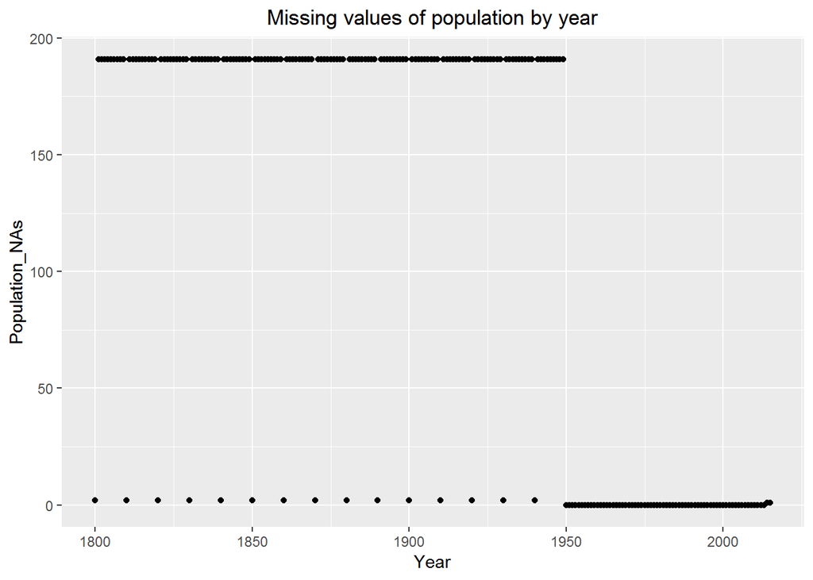

```r
#Using groupby, summarize and pipe operator for the analysis

#Grouping the data by year and computing the number of countries, number of missing values for income and population
missing <- Data %>%
group_by(Year) %>%
summarise(
  countn = n(),
  Income_NAs = sum(is.na(income)),
  Population_NAs = sum(is.na(population))
)

#Using ggplot to plot the number of missing values by year for population
ggplot(data = missing) +
  geom_point(mapping = aes(x = Year, y = Population_NAs)) + ggtitle("Missing values of population by year")+theme(plot.title = element_text(hjust = 0.5))
```

As expected there are very few missing values for population after the year 1950. However, we notice an interesting pattern in our population data. It is observed that most countries have population data once every 10 years before 1950. Therefore, when we need to analyze the population data, we can only use the population once every 10 years before 1950

Let us now understand the missing values in the incomes.

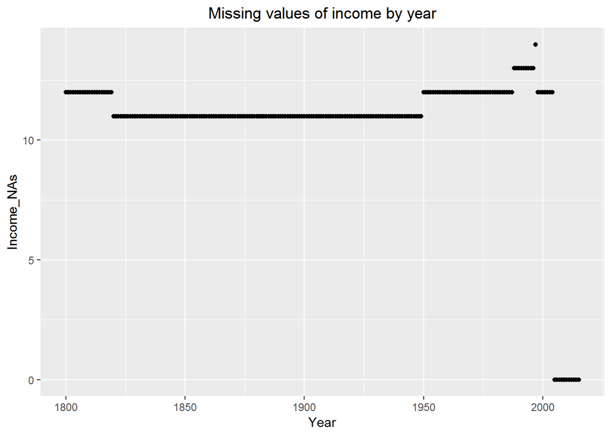

```r
#Using ggplot to plot the number of missing values by year for income
ggplot(data = missing) +
  geom_point(mapping = aes(x = Year, y = Income_NAs))+ ggtitle("Missing values of income by year")+theme(plot.title = element_text(hjust = 0.5))
```

Looking at the plot for missing values of income it appears that income is always missing for a certain few countries. Let us investigate further.

```r
#Grouping the data by countries to investigate missing values of incomes. Using the pipe operator in conjunction with groupby, summarize and filter
missingincome <- Data %>%
group_by(Country) %>%
summarise(
  countn = n(),
  Income_NA2 = sum(is.na(income))
)%>%
filter(Income_NA2>0)
missingincome
```

```
## # A tibble: 15 x 3
##    Country               countn Income_NA2
##    <chr>                  <int>      <int>
##  1 Aland                     10         10
##  2 Channel Islands           55         55
##  3 Croatia                  216         20
##  4 French Guiana            205        205
##  5 French Polynesia         205        205
##  6 Guadeloupe               205        205
##  7 Guam                     205        205
##  8 Martinique               205        205
##  9 Mayotte                  205        205
## 10 Netherlands Antilles     205        205
## 11 New Caledonia            205        205
## 12 Reunion                  205        205
## 13 Tokelau                    1          1
## 14 Virgin Islands (U.S.)    205        205
## 15 Western Sahara           205        205
```

From the data above, it is observed that income data is only missing for a total of 15 countries in our dataset of 197 countries. It is also observed that for almost all the countries the income field is missing for all observations. Croatia is the only exception which has income missing for 20 of the 216 observations. For all analyses with income, we can just exclude these countries with missing incomes. They form only a fraction of the dataset.

Let us now understand the distribution of the various regions and how countries are distributed within the regions.

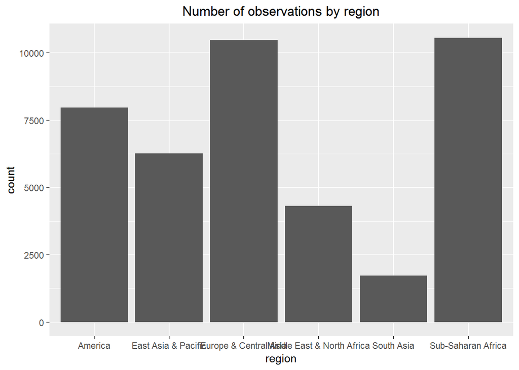

```r
#Plotting the number of observations by region to understand the spread of countries
ggplot(data = Data) +
  geom_bar(mapping = aes(x = region))+theme(plot.title = element_text(hjust = 0.5))+ggtitle("Number of observations by region")
```

As it can be observed from the plot, there is a significant imbalance in the data available. South Asia has the least number of observations with 1728 observations. Sub-Saharan Africa has the most observations with 10562 followed closely by Europe & Central Asia.

```r
#Using the previously created missing dataframe which contains data grouped by year to identify the year with all 197 countries
missing$Year [missing$countn == 197]
```

```
## [1] 1997
```

We also find that there is only 1 year in the entire dataset with all the 197 countries. Using that year we pull the number of countries by region.

```r
#Using the year of 1997 to identify the number of countries in each region
region <- Data %>%
group_by(Year,region) %>%
summarise(
  countn = n()
) %>%
  filter(Year == 1997)
region
```

```
## # A tibble: 6 x 3
## # Groups:   Year [1]
##    Year region                     countn
##   <int> <chr>                       <int>
## 1  1997 America                        38
## 2  1997 East Asia & Pacific            31
## 3  1997 Europe & Central Asia          51
## 4  1997 Middle East & North Africa     20
## 5  1997 South Asia                      8
## 6  1997 Sub-Saharan Africa             49
```

# Univariate plots

## Life expectancy

Life expectancy data denotes the life expectancy of the respective country measured at a particular point in time. We do not have any problems with the life expectancy field as data is present for all the observations.

Let us plot the life expectancy data by regin to understand how the life expectancy has changed over the years.

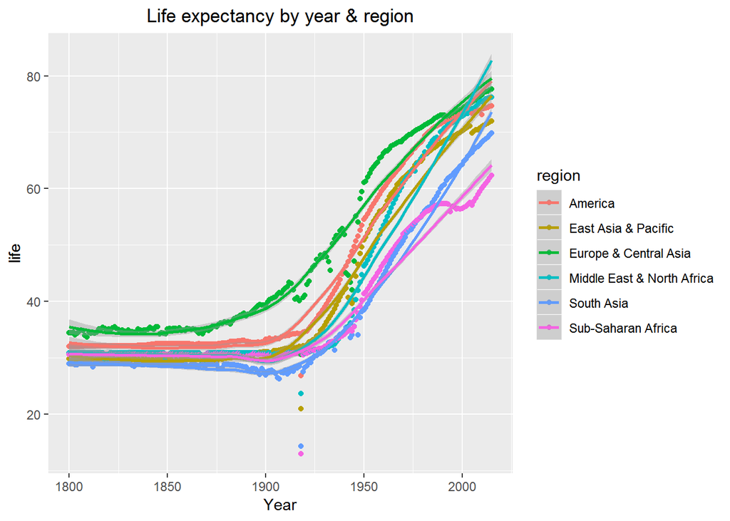

```r
#Grouping the data by region and calculating the mean to analyze the life expectancy
byregion <- Data %>%
group_by(Year,region) %>%
summarise(
  countn = n(),
  life = mean(life, na.RM = TRUE))

#Plotting a line plot for each region  by year
ggplot(data = byregion, aes(x = Year, y = life,color = region)) +
  geom_point() + geom_smooth() + ggtitle("Life expectancy by year & region")+theme(plot.title = element_text(hjust = 0.5))
```

From the line plot, it is observed that the life expectancy is increasing in a similar fashion for all regions. Some unique patterns are observed during the war years where the life expectancy has dropped significantly. Sub-Saharan Africa countries show a significant change in the pattern after the 1980’s. Let us plot out each region separately to identify if there is any specific outlier causing it.

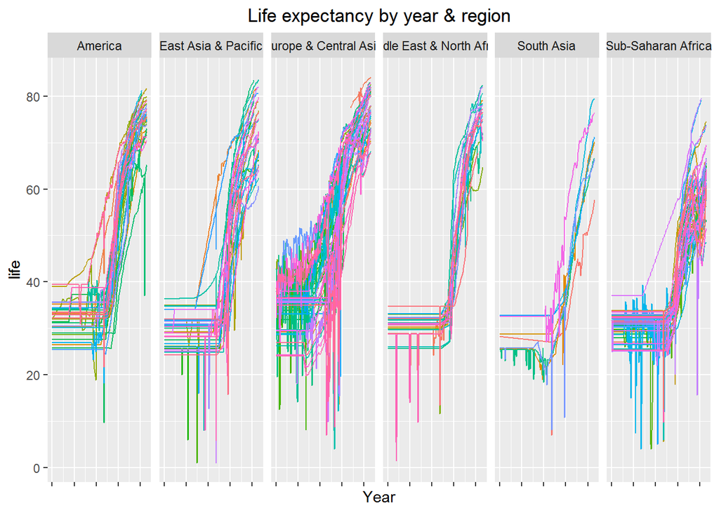

```r
#Plotting life expectancy by region
#Using the theme argument to hide the legend and the x-axis tickmark labels
ggplot(data = Data, aes(x = Year, y = life,color = Country)) +
  geom_line() + facet_grid(.~region) + ggtitle("Life expectancy by year & region")+ theme(legend.position="none",axis.text.x = element_blank(),plot.title = element_text(hjust = 0.5))
```

In the plots above, each colored line represents a country. We can identify that there are no signficant outliers or wrong observations that could be skewing the Sub Saharan Africa data.

Let us use a box plot to summarize the results of life expectancy data based on the year of 2015 which is the most recent data in our dataset.

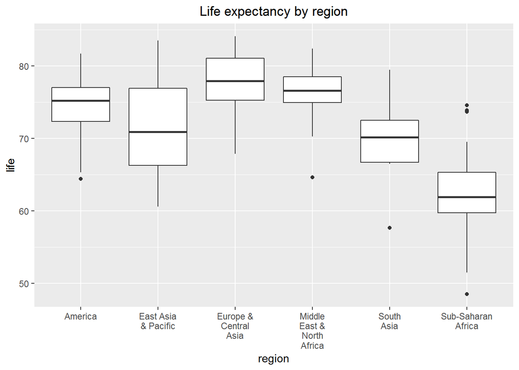

```r
#Boxplot of life expectancy by region for year 2015
Data%>%
  filter(Year == 2015)%>%
ggplot(mapping = aes(x = region, y = life)) +
  geom_boxplot()+scale_x_discrete(labels = function(region) lapply(strwrap(region, width = 10, simplify = FALSE), paste, collapse="\n"))+theme(plot.title = element_text(hjust = 0.5))+ggtitle("Life expectancy by region")
```

Europe and Central Asia region has the highest median life expectancy of all regions followed by Middle East & North Africa. South Asia and Sub-Saharan Africa have the lowest life expectancy by region.

## Income

Moving on to univariate analysis of income, we recall that there were several countries that had the income variable missing in the dataset. Let us analyze the mean income by region.

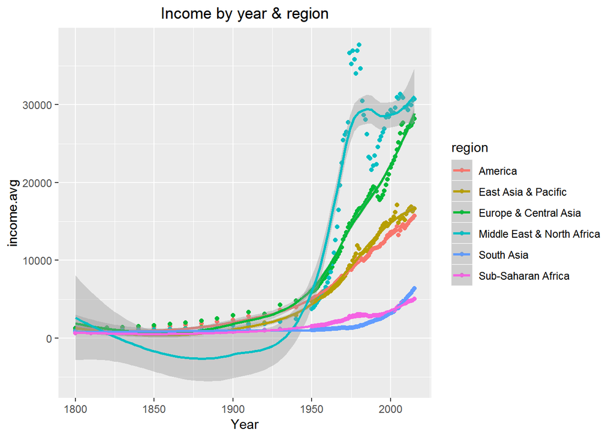

```r
#Grouping the data by region and calculating the mean salary

#Data with NAs are first removed before analyzing the data
byregion3 <- na.omit(Data) %>%
group_by(Year,region) %>%
summarise(
  income.avg = mean(income, na.RM = TRUE))

#Plotting a line plot for each region by year
ggplot(data = byregion3, aes(x = Year, y = income.avg,color = region)) + geom_point()+
geom_smooth(method="loess") + ggtitle("Income by year & region")+theme(plot.title = element_text(hjust = 0.5))
```

Three distinct clusters are observed by looking at the region plots. It is observed that Middle East and North African countries have the highest mean income. Europe and Central Asia countries have a similarly high income. America and East Asia and Pacific countries have similar average incomes whereas South Asia and Sub Saharan African countries have the least income.

Let us now look at the charts by country and box and whisker plots to understand if there are significant outliers in the data.

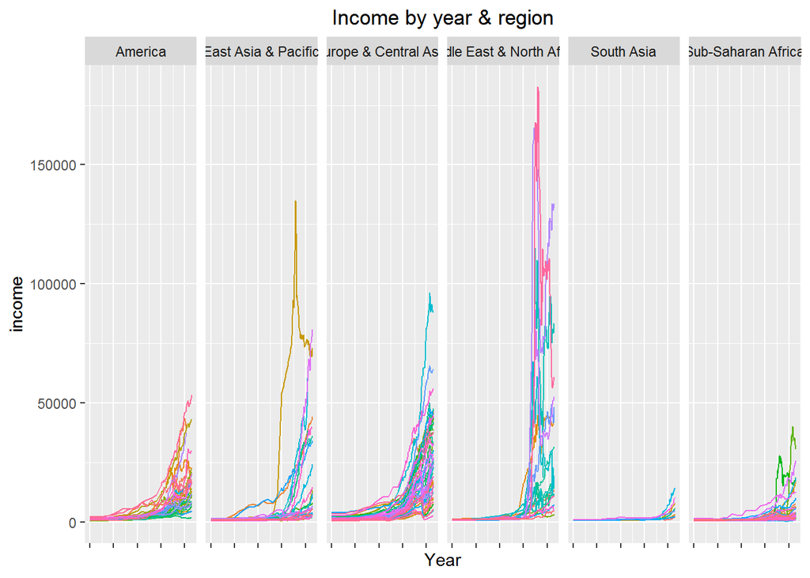

```r
#Plotting income by region and country
#Using the theme argument to hide the legend and the x-axis tickmark labels
ggplot(data = na.omit(Data), aes(x = Year, y = income,color = Country)) +
  geom_line() + facet_grid(.~region) + ggtitle("Income by year & region")+ theme(legend.position="none",axis.text.x = element_blank(),plot.title = element_text(hjust = 0.5))
```

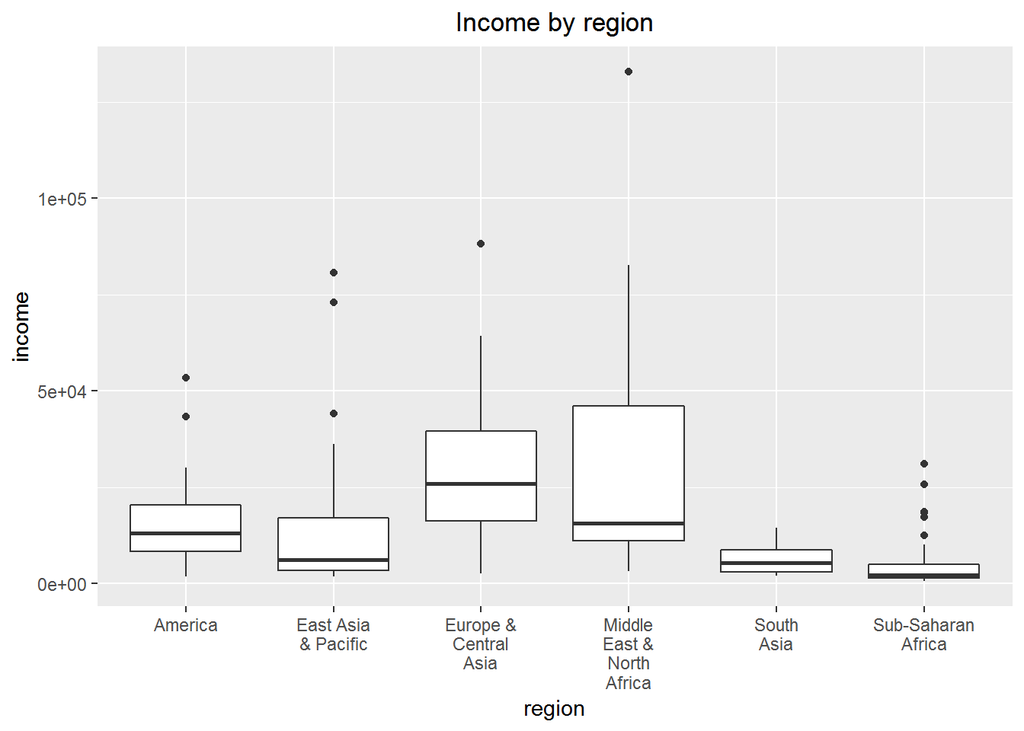

```r
#Boxplot of income by region for year 2015
na.omit(Data)%>%
  filter(Year == 2015)%>%
ggplot(mapping = aes(x = region, y = income)) +
  geom_boxplot()+scale_x_discrete(labels = function(region) lapply(strwrap(region, width = 10, simplify = FALSE), paste, collapse="\n"))+theme(plot.title = element_text(hjust = 0.5))+ggtitle("Income by region")
```

```r
#Identifying outliers by region
na.omit(Data)%>%
  filter(Year == 2015)%>%
  group_by(region) %>%
  top_n(3,income)
```

```
## # A tibble: 18 x 6
## # Groups:   region [6]
##    Country               Year  life population income region
##    <chr>                <int> <dbl>      <dbl>  <dbl> <chr>
##  1 Australia             2015  81.8   23968973  44056 East Asia & Pacific
##  2 Bhutan                2015  70.2     774830   7983 South Asia
##  3 Brunei                2015  78.7     423188  73003 East Asia & Pacific
##  4 Canada                2015  81.7   35939927  43294 America
##  5 Equatorial Guinea     2015  60.6     845060  31087 Sub-Saharan Africa
##  6 Gabon                 2015  60.5    1725292  18627 Sub-Saharan Africa
##  7 Kuwait                2015  80.7    3892115  82633 Middle East & North~
##  8 Luxembourg            2015  81.1     567110  88314 Europe & Central As~
##  9 Maldives              2015  79.5     363657  14408 South Asia
## 10 Norway                2015  81.6    5210967  64304 Europe & Central As~
## 11 Qatar                 2015  82      2235355 132877 Middle East & North~
## 12 Seychelles            2015  73.7      96471  25684 Sub-Saharan Africa
## 13 Singapore             2015  82.1    5603740  80794 East Asia & Pacific
## 14 Sri Lanka             2015  76.5   20715010  10624 South Asia
## 15 Switzerland           2015  82.9    8298663  56118 Europe & Central As~
## 16 Trinidad and Tobago   2015  71.4    1360088  30113 America
## 17 United Arab Emirates  2015  76.6    9156963  60749 Middle East & North~
## 18 United States         2015  79.1  321773631  53354 America
```

## Population

Population metric is explored by looking at a simple line chart by region keeping in mind that population metric was only recorded once every 10 years till 1950.

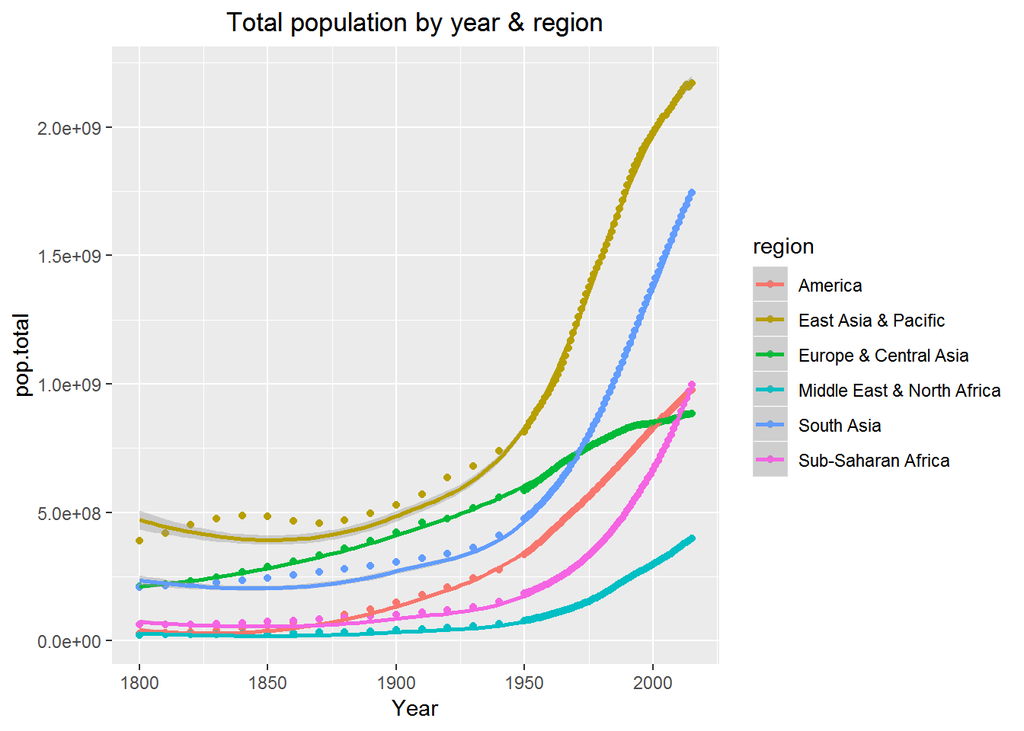

```r
#Grouping the data by region and calculating the total population

#Data with NAs are first removed before analyzing the data
byregion2 <- na.omit(Data) %>%
group_by(Year,region) %>%
summarise(
  pop.total = sum(population, na.RM = TRUE))

#Plotting a line plot for each region by year
ggplot(data = byregion2, aes(x = Year, y = pop.total,color = region)) + geom_point()+
geom_smooth(method="loess") + ggtitle("Total population by year & region")+theme(plot.title = element_text(hjust = 0.5))
```

The population seems to be increasing exponentially for most of the regions following a similar curve. Particularly significant growth is observed for East Asia & Pacific region, South Asia and Sub Saharan Africa.

Similar to the life expectancy, let us look at the charts by country and box and whisker plots to understand if there are significant outliers in the data.

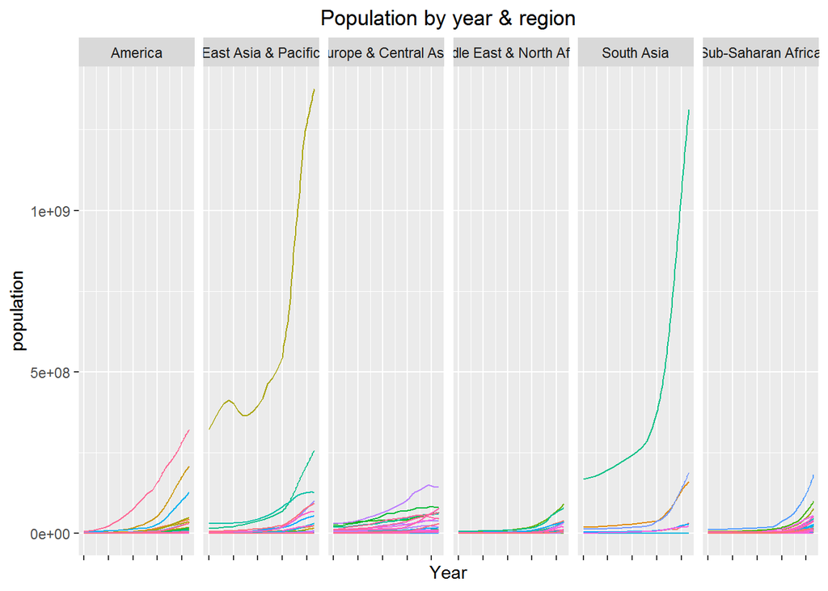

```r
#Plotting population by region and country
#Using the theme argument to hide the legend and the x-axis tickmark labels
ggplot(data = na.omit(Data), aes(x = Year, y = population,color = Country)) +
  geom_line() + facet_grid(.~region) + ggtitle("Population by year & region")+ theme(legend.position="none",axis.text.x = element_blank(),plot.title = element_text(hjust = 0.5))
```

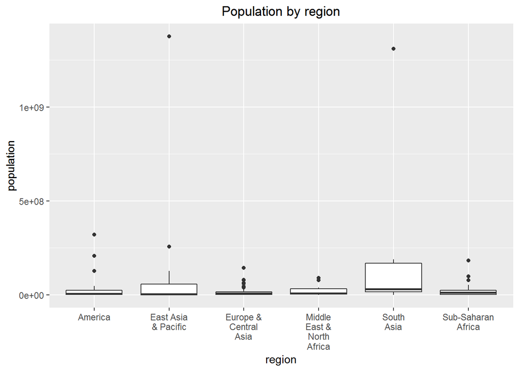

```r
#Boxplot of population by region for year 2015
na.omit(Data)%>%
  filter(Year == 2015)%>%
ggplot(mapping = aes(x = region, y = population)) +
  geom_boxplot()+scale_x_discrete(labels = function(region) lapply(strwrap(region, width = 10, simplify = FALSE), paste, collapse="\n"))+theme(plot.title = element_text(hjust = 0.5))+ggtitle("Population by region")
```

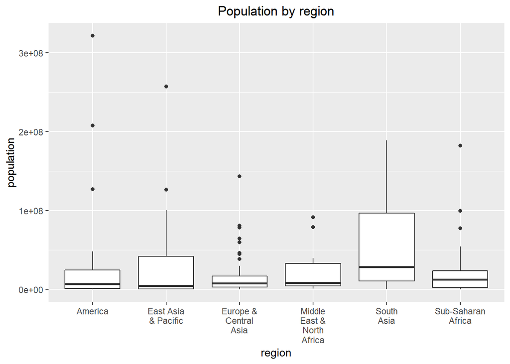

```r
#Boxplot of population by region for year 2015 ommiting India and China
na.omit(Data)%>%
  filter(Year == 2015, Country != "India", Country != "China")%>%
ggplot(mapping = aes(x = region, y = population)) +
  geom_boxplot()+scale_x_discrete(labels = function(region) lapply(strwrap(region, width = 10, simplify = FALSE), paste, collapse="\n"))+theme(plot.title = element_text(hjust = 0.5))+ggtitle("Population by region")
```

The box plot still has significant outliers which leads us to conclude that population is significantly skewed by country. We can confirm this by drawing a histogram of our data.

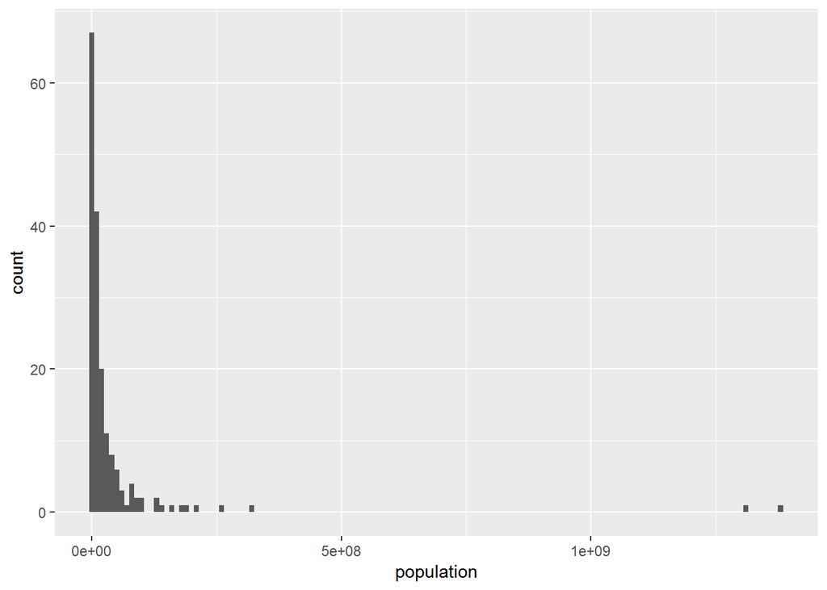

```r
#Histogram of population with a bin width of 10000000
na.omit(Data)%>%
  filter(Year == 2015)%>%
ggplot() +
  geom_histogram(mapping = aes(x = population), binwidth = 10000000)
```

The data is very skewed as expected. Let us zoom into exlcude the outliers and identify the countries with high population that are outliers in addition to India and China.

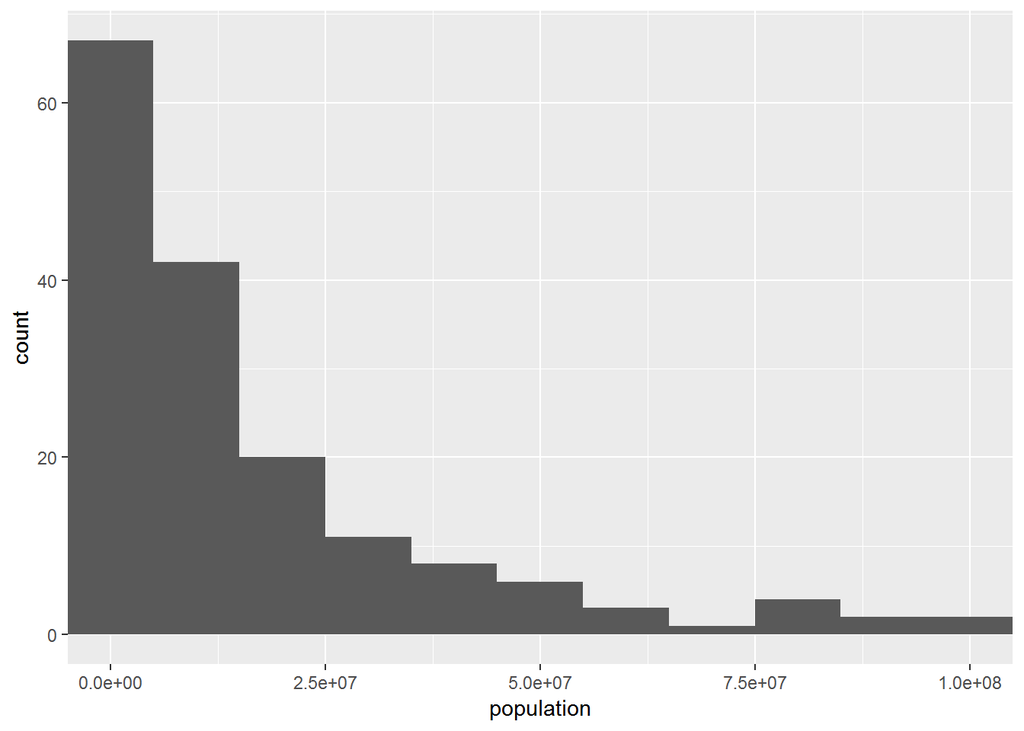

```r
#Histogram of population with a bin width of 10000000 zooming in

na.omit(Data)%>%
  filter(Year == 2015)%>%
ggplot() +
  geom_histogram(mapping = aes(x = population), binwidth = 10000000)+coord_cartesian(xlim = c(0, 100000000))
```

```r
#Filtering outliers

unusual <- na.omit(Data) %>%
  filter(Year == 2015,population > 100000000 | population<100000) %>%
  select(region,Country, population) %>%
  arrange(desc(population))
unusual
```

```
## # A tibble: 17 x 3
##    region                Country             population
##    <chr>                 <chr>                    <dbl>
##  1 East Asia & Pacific   China               1376048943
##  2 South Asia            India               1311050527
##  3 America               United States        321773631
##  4 East Asia & Pacific   Indonesia            257563815
##  5 America               Brazil               207847528
##  6 South Asia            Pakistan             188924874
##  7 Sub-Saharan Africa    Nigeria              182201962
##  8 South Asia            Bangladesh           160995642
##  9 Europe & Central Asia Russia               143456918
## 10 America               Mexico               127017224
## 11 East Asia & Pacific   Japan                126573481
## 12 East Asia & Pacific   Philippines          100699395
## 13 Sub-Saharan Africa    Seychelles               96471
## 14 America               Antigua and Barbuda      91818
## 15 America               Dominica                 72680
## 16 Europe & Central Asia Andorra                  70473
## 17 East Asia & Pacific   Marshall Islands         52993
```

# Covariation between variables for the countries

Let us look for patterns in the data to understand if there is any relationship between the population, income and life expectancy. We can do this using scatter plots.

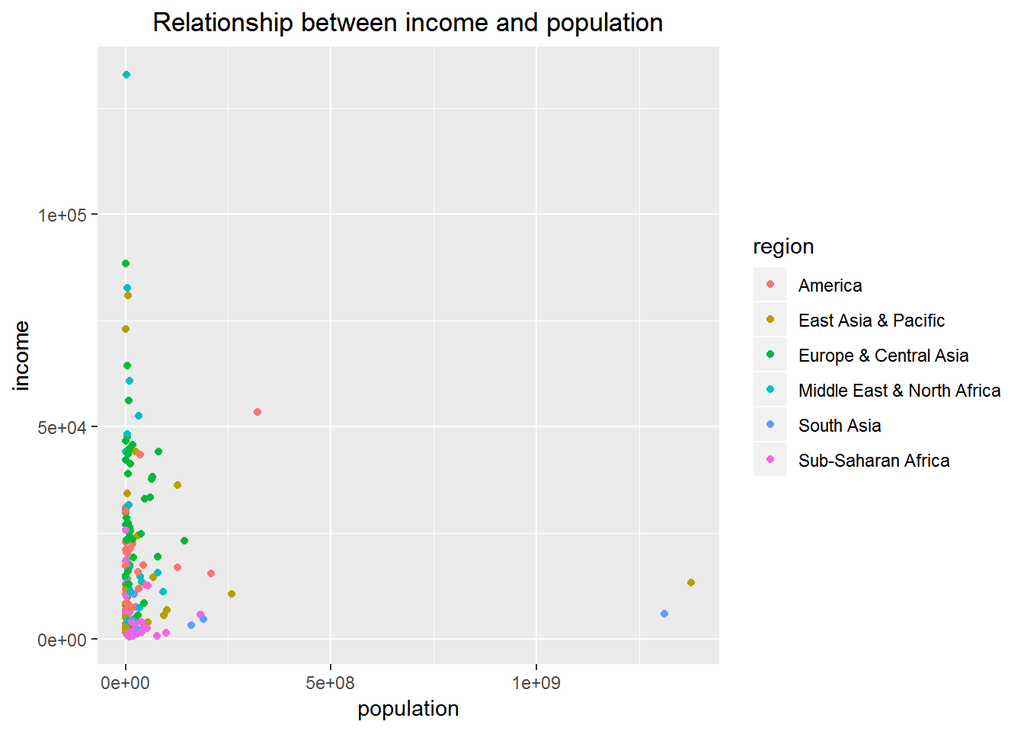

```r
#Scatter plot between income and population
na.omit(Data)%>%
  filter(Year == 2015)%>%
ggplot() +
  geom_point(mapping = aes(x = population, y = income,color=region))+theme(plot.title = element_text(hjust = 0.5))+ggtitle("Relationship between income and population")
```

There does not look to be any pattern that can be observed from the population and income. Let us proceed to looking at the relationship between population and life expectancy.

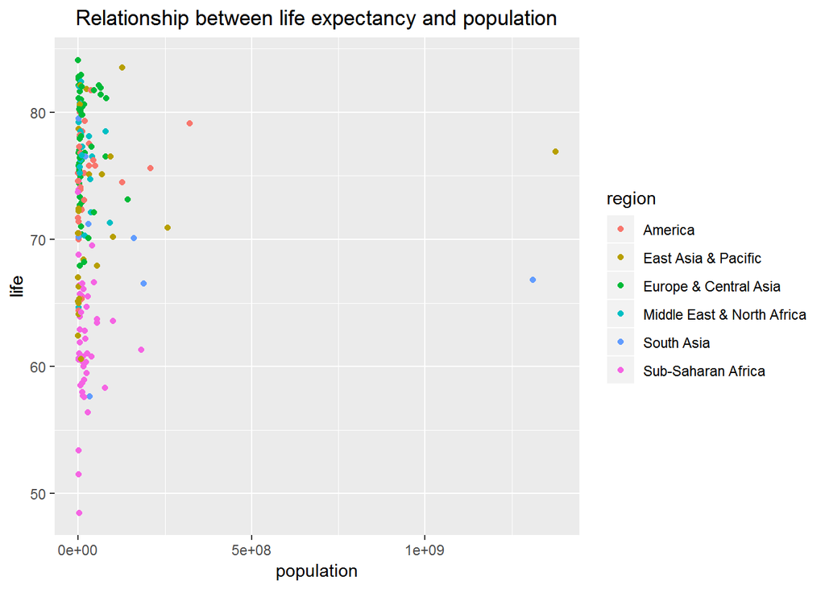

```r
#Scatter plot between life expectancy and population
na.omit(Data)%>%
  filter(Year == 2015)%>%
ggplot() +
  geom_point(mapping = aes(x = population, y = life,color=region))+theme(plot.title = element_text(hjust = 0.5))+ggtitle("Relationship between life expectancy and population")
```

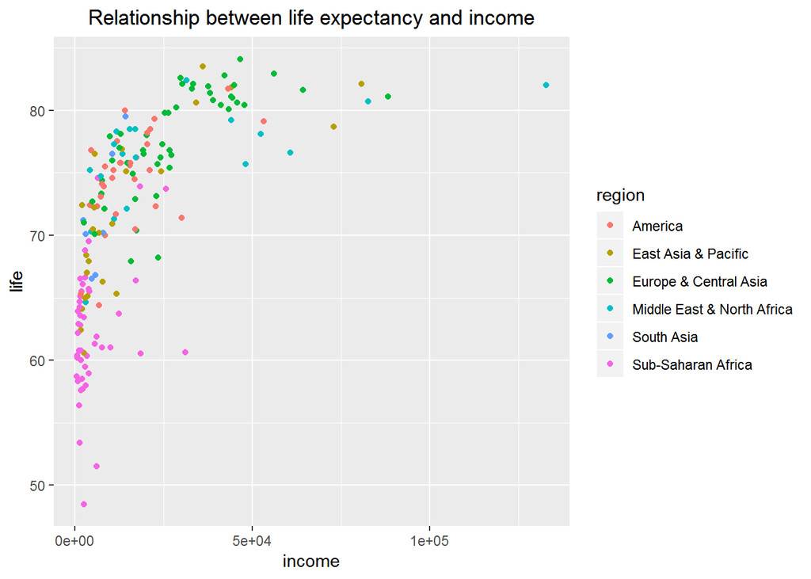

```r
#Scatter plot between life expectancy and income
na.omit(Data)%>%
  filter(Year == 2015)%>%
ggplot() +
  geom_point(mapping = aes(x = income, y = life,color=region))+theme(plot.title = element_text(hjust = 0.5))+ggtitle("Relationship between life expectancy and income")
```

There seems to be a marginal correlation between the life expectanct and income. As income goes up, there also is an increase observed in life expectancy.This pattern seems to be across regions and not specific to one particular region.

# Clustering analysis

For our clustering analysis, we will use the metrics of population, income and life expectancy to find clusters of countries. We will use the k means clustering method. Let us load the data and get it in the required format for clustering analysis.

```r
#Removing the NAs from the data and creating a dataset with just 2015 data
cluster.data <- as.data.frame(Data) %>%
na.omit(Data)%>%
  filter(Year == 2015)

#Scaling the numeric variables
cluster.data$population <- scale(cluster.data$population)
cluster.data$income <- scale(cluster.data$income)
cluster.data$life <- scale(cluster.data$life)

#Moving the country field to the rownames
rownames(cluster.data) <- cluster.data$Country
cluster.data$Country <- NULL
cluster.data$region <- NULL
cluster.data$Year <- NULL
```

Let us now compute the distance matrix.

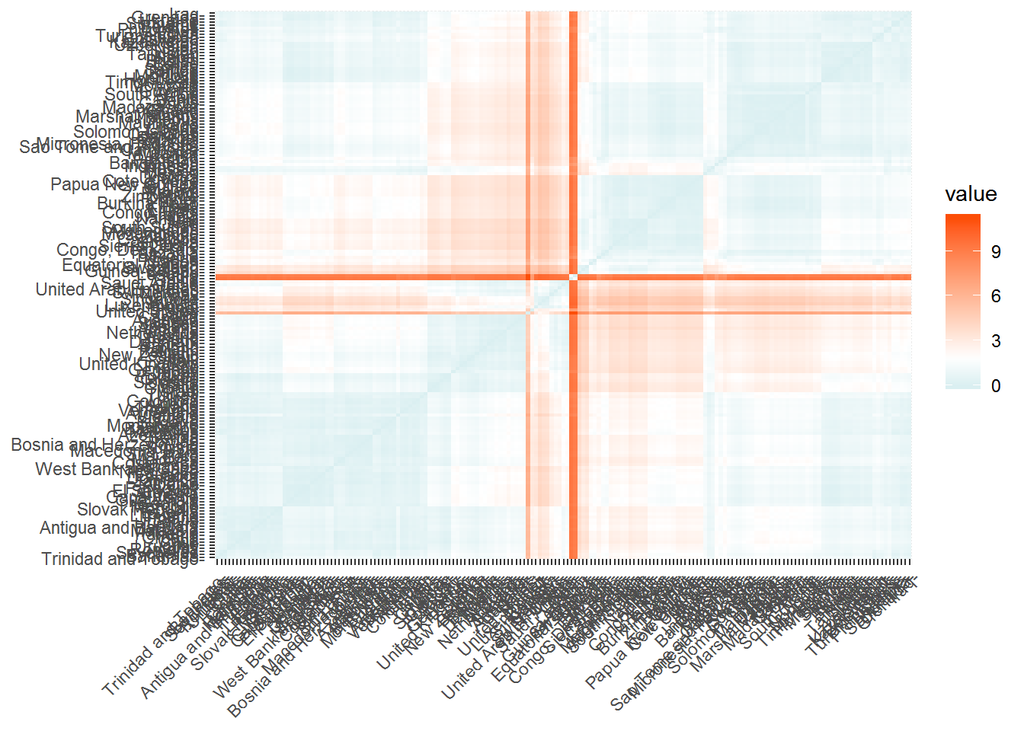

```r
#Computing the distance matrix
distance <- get_dist(cluster.data)
fviz_dist(distance, gradient = list(low = "#00AFBB", mid = "white", high = "#FC4E07"))
```

## Determining the optimal number of clusters

Let us now compute the optimal number of clusters using the various methods we have available.

### Elbow method

Elbow method can be computed this using the fviz_nbclust function as shown below:

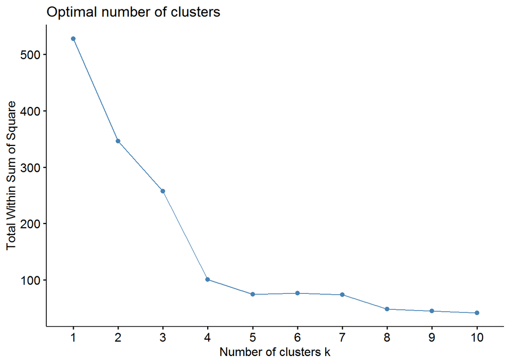

```r
#Using Elbow method to find optimal number of clusters
set.seed(123)
fviz_nbclust(cluster.data, kmeans, method = "wss")
```

This method indicates that the optimal number of clusters is 4 as evidenced by the bend in the elbow.

### Average Silhouette method

Average Silhouette method method can also be computed this using the fviz_nbclust function as shown below:

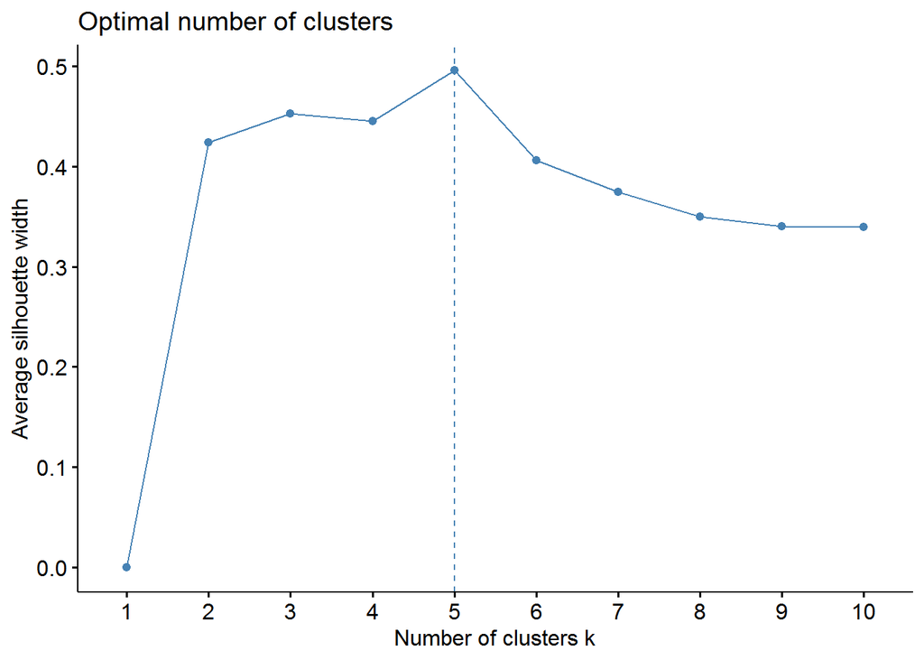

```r
#Using silhouette method to find optimal number of clusters
fviz_nbclust(cluster.data, kmeans, method = "silhouette")
```

This method indicates that the optimal number of clusters is 5.

### Gap statistic method

We can compute this using the clusGap function which provides the gap statistic and a standard error for the output. R code is shown below:

```r
# compute gap statistic
set.seed(123)
gap_stat <- clusGap(cluster.data, FUN = kmeans, nstart = 25,
                    K.max = 20, B = 50)
# Print the result to find optimal number of clusters
print(gap_stat, method = "firstmax")
```

```
## Clustering Gap statistic ["clusGap"] from call:
## clusGap(x = cluster.data, FUNcluster = kmeans, K.max = 20, B = 50,     nstart = 25)
## B=50 simulated reference sets, k = 1..20; spaceH0="scaledPCA"
##  --> Number of clusters (method 'firstmax'): 2
##           logW   E.logW       gap     SE.sim
##  [1,] 4.416592 5.367302 0.9507102 0.02233139
##  [2,] 4.081385 5.102071 1.0206863 0.02255240
##  [3,] 3.936371 4.933076 0.9967055 0.01866109
##  [4,] 3.633193 4.800509 1.1673155 0.01741200
##  [5,] 3.532528 4.714834 1.1823059 0.01804608
##  [6,] 3.414202 4.643755 1.2295530 0.01893996
##  [7,] 3.308290 4.583804 1.2755137 0.01863868
##  [8,] 3.241611 4.528559 1.2869484 0.01843563
##  [9,] 3.186403 4.478605 1.2922013 0.01902247
## [10,] 3.157768 4.432185 1.2744171 0.01806451
## [11,] 3.100391 4.388731 1.2883404 0.01827201
## [12,] 3.044585 4.347535 1.3029496 0.01829251
## [13,] 2.979876 4.309717 1.3298413 0.01943418
## [14,] 2.946283 4.272008 1.3257257 0.01970508
## [15,] 2.882947 4.236916 1.3539694 0.02028465
## [16,] 2.846065 4.204089 1.3580241 0.02083746
## [17,] 2.795123 4.172653 1.3775301 0.02106977
## [18,] 2.770542 4.141596 1.3710542 0.02171703
## [19,] 2.720473 4.112356 1.3918828 0.02217358
## [20,] 2.687767 4.083857 1.3960907 0.02223487
```

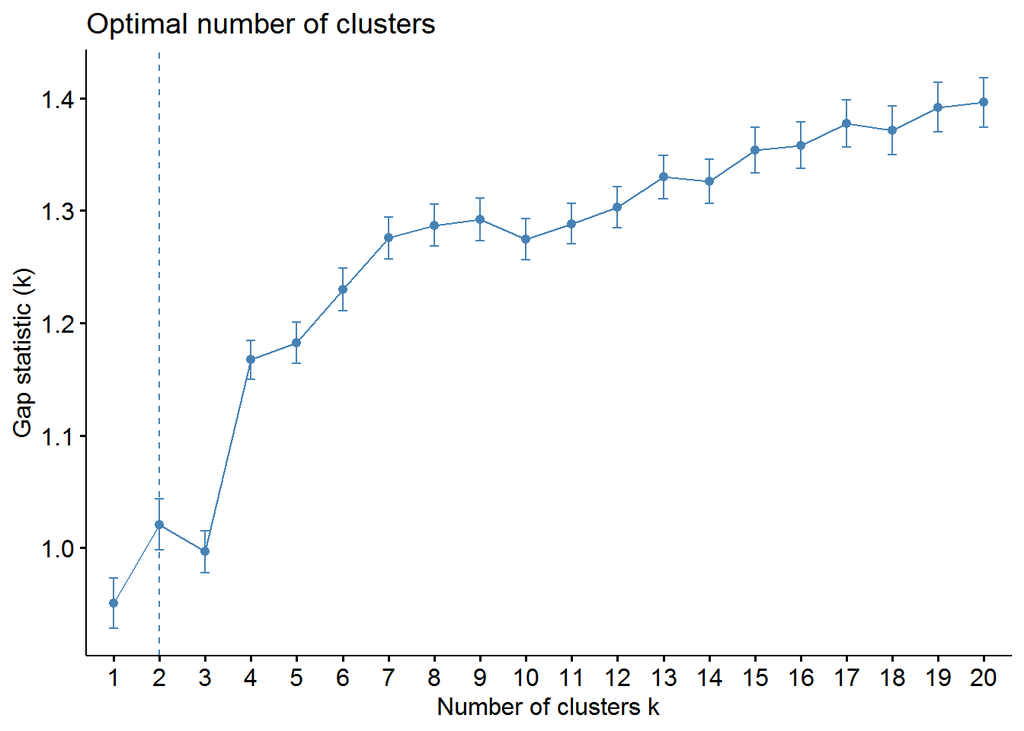

```r
fviz_gap_stat(gap_stat)
```

This method indicates that the optimal number of clusters is 2.

## Final K means clustering

As all of the methods yielded different results, we choose the number of clusters to be 4 or 5. 2 clusters are deemed to not meet the requirements as we want to slice the data differently. Let us continue the clustering analysis with 4 clusters.

```r
#4 clusters
set.seed(123)
final1 <- kmeans(cluster.data, 4, nstart = 25)
print(final1)
```

```
## K-means clustering with 4 clusters of sizes 2, 58, 33, 84
##
## Cluster means:
##          life  population     income
## 1  0.01688323  8.85618099 -0.4056036
## 2 -1.22164045 -0.12650386 -0.6819283
## 3  1.19254721 -0.07470201  1.6803880
## 4  0.37461097 -0.09416633 -0.1796399
##
## Clustering vector:
##            Afghanistan                Albania                Algeria
##                      2                      4                      4
##                Andorra                 Angola    Antigua and Barbuda
##                      3                      2                      4
##              Argentina                Armenia              Australia
##                      4                      4                      3
##                Austria             Azerbaijan                Bahamas
##                      3                      4                      4
##                Bahrain             Bangladesh               Barbados
##                      3                      4                      4
##                Belarus                Belgium                 Belize
##                      4                      3                      4
##                  Benin                 Bhutan                Bolivia
##                      2                      4                      4
## Bosnia and Herzegovina               Botswana                 Brazil
##                      4                      2                      4
##                 Brunei               Bulgaria           Burkina Faso
##                      3                      4                      2
##                Burundi               Cambodia               Cameroon
##                      2                      2                      2
##                 Canada             Cape Verde                   Chad
##                      3                      4                      2
##                  Chile                  China               Colombia
##                      4                      1                      4
##                Comoros       Congo, Dem. Rep.            Congo, Rep.
##                      2                      2                      2
##             Costa Rica          Cote d'Ivoire                Croatia
##                      4                      2                      4
##                   Cuba                 Cyprus                Denmark
##                      4                      3                      3
```

[output cut: 83 more lines]

```
##                      3                      4                      4
##                Vanuatu              Venezuela                Vietnam
##                      2                      4                      4
##     West Bank and Gaza                 Zambia               Zimbabwe
##                      4                      2                      2
##
## Within cluster sum of squares by cluster:
## [1]  1.011936 23.165330 44.056704 32.571795
##  (between_SS / total_SS =  80.9 %)
##
## Available components:
##
## [1] "cluster"      "centers"      "totss"        "withinss"
## [5] "tot.withinss" "betweenss"    "size"         "iter"
## [9] "ifault"
```

We visualize the results using fviz_cluster function.

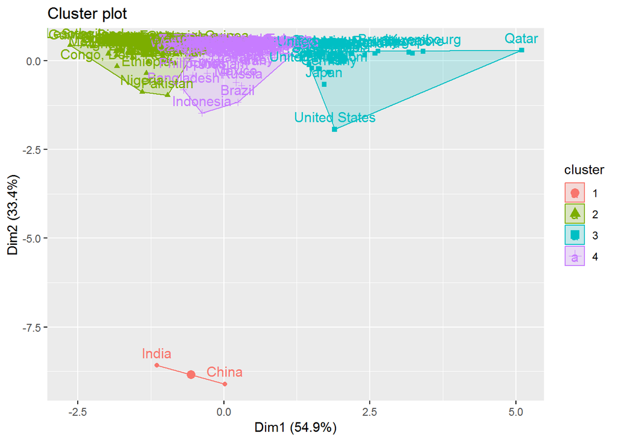

```r
#Visualizing the clusters
fviz_cluster(final1, data = cluster.data)
```

```r
#4 clusters after removing the population metric

cluster.data$population <- NULL
set.seed(123)
final2 <- kmeans(cluster.data, 4, nstart = 25)
print(final2)
```

```
## K-means clustering with 4 clusters of sizes 31, 82, 5, 59
##
## Cluster means:
##         life     income
## 1  1.1809129  1.2263007
## 2  0.3532411 -0.2038741
## 3  1.1826543  3.7698417
## 4 -1.2116499 -0.6804552
##
## Clustering vector:
##            Afghanistan                Albania                Algeria
##                      4                      2                      2
##                Andorra                 Angola    Antigua and Barbuda
##                      1                      4                      2
##              Argentina                Armenia              Australia
##                      2                      2                      1
##                Austria             Azerbaijan                Bahamas
##                      1                      2                      2
##                Bahrain             Bangladesh               Barbados
##                      1                      2                      2
##                Belarus                Belgium                 Belize
##                      2                      1                      2
##                  Benin                 Bhutan                Bolivia
##                      4                      2                      2
## Bosnia and Herzegovina               Botswana                 Brazil
##                      2                      4                      2
##                 Brunei               Bulgaria           Burkina Faso
##                      3                      2                      4
##                Burundi               Cambodia               Cameroon
##                      4                      4                      4
##                 Canada             Cape Verde                   Chad
##                      1                      2                      4
##                  Chile                  China               Colombia
##                      2                      2                      2
##                Comoros       Congo, Dem. Rep.            Congo, Rep.
##                      4                      4                      4
##             Costa Rica          Cote d'Ivoire                Croatia
##                      2                      4                      2
##                   Cuba                 Cyprus                Denmark
##                      2                      1                      1
```

[output cut: 83 more lines]

```
##                      1                      2                      2
##                Vanuatu              Venezuela                Vietnam
##                      4                      2                      2
##     West Bank and Gaza                 Zambia               Zimbabwe
##                      2                      4                      4
##
## Within cluster sum of squares by cluster:
## [1]  8.977359 21.637546  5.992096 19.915714
##  (between_SS / total_SS =  83.9 %)
##
## Available components:
##
## [1] "cluster"      "centers"      "totss"        "withinss"
## [5] "tot.withinss" "betweenss"    "size"         "iter"
## [9] "ifault"
```

```r
#Number of countries in each cluster
final2$size
```

```
## [1] 31 82  5 59
```

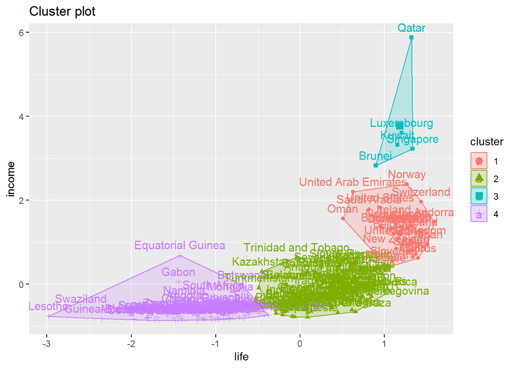

```r
#Visualizing the clusters after removing the population metric
fviz_cluster(final2, data = cluster.data)
```

These results look to be more acceptable as there are better distribution of countries between the 4 clusters. Countries in cluster 3 consists of developed countries which have life expectancy similar to cluster 1 but higher incomes. Cluster 3 is the smallest cluster and has only 5 countries. Qatar, Luxembourg, Kuwait, Singapore and Brunei are the only countries in this cluster. It is noticeable that these countries have significantly smaller populations.

Cluster 1 have the highest life expectancy similar to cluster 3. They also have income and can be classified as developed countries as well. There are a total of 31 countries in this cluster. Some of the prominent countries in this group are United States, United Kingdom, United Arab Emirates, Japan, France and Italy.

Cluster 2 has the largest number of countries with 82 and has a wide variety of developing countries. Prominent countries in this group are China, Argentina, Brazil and Mexico.

Group 4 is the group of least developed countries according to the cluster analysis based on income and life expectancy in the year 2015. This group contains 59 countries. Surprisingly India shows up on this list. Other countries include Zimbabwe, South Africa, Pakistan and Namibia.

# Summary

Exploratory data analysis was carried out on the gapminder dataset using various data wrangling techniques. Analysis was done to identify the countries that have the highest life expectancy and income. Data was also analayzed to find patterns over the years and to help identify countries that were different than their region. It was found that countries belonging to the Europe & Central Asia region and Middle East & North Africa region had the highest meadian life expectancy and income. South Asia and East Asia countries performed significantly better on population. This was skewed by a large extent by India and China which have significantly higher populations. Cluster analysis was performed to identify groups of countries based on their life expectancy and income. Based on these 2 metrics 4 clusters were formed using the K means clustering method. Most recent data of 2015 was used for this analysis. This grouped the countries based on which countries have the higher life expectancy and income.